# QTM 151 - Quiz 4

## Try to submit as an HTML file

Print your name below

```python
# Write your answer here

print("Aimee Zhang")
```

```
Aimee Zhang
```

This quiz is open book

- You can use the lecture notes
- You will get partial credit for attempting the questions
- To get full credit, the code should run as intended
- You should NOT communicate with other students

Print the following message:

"I will abide by Emory's code of conduct"

```python
# Write your answer here:
print("I will abide by Emory's code of conduct")
```

```
I will abide by Emory's code of conduct
```

Import the libraries "matplotlib.pyplot" and "pandas"

```python
# Write your answer here

import matplotlib.pyplot as plt
import pandas as pd
```

In this quiz you will work with data on exchange rates,  
for the following currencies:

- 1 euro (EUR) to dollar (USD)
- 1 pound (GPB) to dollar (USD).

(a) Import and parse dates

- Import the dataset "currencies.csv"
- Parse the "date_string" column with `pd.to_datetime()`
- To get full points, set the "format" option using wildcards as in Lecture 16.

```python
# Write your own code
currencies = pd.read_csv("data_raw/currencies.csv")
currencies["datetime"] = pd.to_datetime(currencies["date_string"])
currencies["datetime"] = currencies["datetime"].dt.strftime("%A, %b %d, %Y")
```

(b) Plot multiple time series

- Create a line plot plot which has the "gbp_to_usd" and "eur_to_usd" on the y-axis

and the date on the x-axis

- Label the x-axis, the y-axis, and the title
- Add a legend and set the names to "1 Euro to USD" and "1 GPB to USD"

Hint: See Lecture 18 for how to plot multiple columns  
Hint: Remember to include the legend names as a list `[...]`

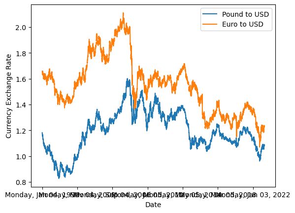

```python
# Write your own code

currencies[["datetime","gbp_to_usd","eur_to_usd"]].set_index("datetime").plot()
plt.xlabel("Date")
plt.ylabel("Currency Exchange Rate")
plt.legend(["Pound to USD","Euro to USD"])
```

(c) Compute growth rates

- Calculate a new column "growth_euro" which computes the percentage daily

growth rate of "eur_to_usd".

Hint: Use `.diff()` and `.shift(1)`

```python
# Write your own code

currencies["growth_euro"] = currencies["eur_to_usd"].diff()/currencies["eur_to_usd"].shift(1) * 100
```

(d) Flag subset of data and plot

- Create a boolean colum (True/False) "bool_cond" which checks whether

"growth_euro" had a value greater than 2 or less than -2

- Generate a line plot with the "growth_euro" series, label the axes and the title
- Use the command `plt.fill_between()` as in Lecture 18 to create a shaded region

for time periods where "bool_cond" is true.

[figure not shown]

```python
# Write your own code

currencies["bool_cond"]  = (currencies["growth_euro"] > 2) | (currencies["growth_euro"] < -2)
plt.plot("datetime", "growth_euro", data = currencies)
plt.xlabel("Date")
plt.ylabel("Euro to USD Growth Rate")
plt.title("Euro to USD Growth Rate > 2 or < -2")

vec_y = currencies["growth_euro"]
plt.fill_between(x= currencies["datetime"],
                 y1 = vec_y.min(),
                 y2 = vec_y.max(),
                 where = currencies["bool_cond"],
                 alpha = 0.2,color = "red")

plt.show()
```

(e) Aggregate dataset by time period

- Create an object "month_config" that uses `pd.Grouper()`, setting the key to

the column "date" and freq to "m" (month)

- Follow the instructions in Lecture 16 to compute an aggregate dataset

by month which computes the standard deviation of "eur_to_usd"

- Display the dataset

```python
# Write your own code

month_config = pd.Grouper(key='datetime', freq='m')
monthlydata = (currencies
               .groupby(month_config)
               .agg(std = ("eur_to_usd","std"))
               .reset_index())
```

[output not shown]

[output cut: 15 more lines]

[output not shown]

(f) Convert a dataset to long format

- Convert the currencies dataset to long format using the following inputs

```
var_name   = "type",
value_name = "exchange_rate",
id_vars    = "date",
value_vars = ["eur_to_usd","gbp_to_usd"]
```

- Display the dataset

Hint: See Lecture 18 for details on `pd.melt()`

```python
# Write your own code

currencies_long = pd.melt(currencies,
                         var_name = "type",
                         value_name = "exchange_rate",
                         id_vars='datetime',
                         value_vars=['eur_to_usd','gbp_to_usd'])
currencies_long
```

|  | datetime | type | exchange_rate |
| --- | --- | --- | --- |
| 0 | Monday, Jan 04, 1999 | eur_to_usd | 1.6581 |
| 1 | Tuesday, Jan 05, 1999 | eur_to_usd | 1.6566 |
| 2 | Wednesday, Jan 06, 1999 | eur_to_usd | 1.6547 |
| 3 | Thursday, Jan 07, 1999 | eur_to_usd | 1.6495 |
| 4 | Friday, Jan 08, 1999 | eur_to_usd | 1.6405 |
| ... | ... | ... | ... |
| 12645 | Monday, Mar 27, 2023 | gbp_to_usd | 1.0789 |
| 12646 | Tuesday, Mar 28, 2023 | gbp_to_usd | 1.0844 |
| 12647 | Wednesday, Mar 29, 2023 | gbp_to_usd | 1.0826 |
| 12648 | Thursday, Mar 30, 2023 | gbp_to_usd | 1.0899 |
| 12649 | Friday, Mar 31, 2023 | gbp_to_usd | 1.0872 |

12650 rows × 3 columns